# Social Media Post Analysis: Optimizing Client Engagement

Author: Karo Bakhtiyar

Date: September 9th 2025

Project: Social Media Marketing Data Analysis

## Project Overview

**Company**: A social media marketing agency specializing in promoting brands and products online.

**Business Problem**: Clients want to maximize engagement (likes, comments, shares) but don’t know which categories of posts (Food, Travel, Fashion, Fitness, Music, Culture, Family, Health) perform best. The agency needs data-driven insights to optimize posting strategy.

**My Role**: Junior Data Analyst on the social media analytics team.

**Key Business Question**: How do different post categories perform in terms of engagement, and what strategies can improve client reach?

## Project Objectives

1. **Analyze engagement patterns** across different post categories.
2. **Identify high-performing categories** that drive better reach and engagement.
3. **Provide actionable recommendations** to clients for improving social media strategy.
4. **Deliver professional visualizations and insights** for decision-making.

## Expected Deliverables

1. Clear statement of business problem.
2. Description of data generation and cleaning process.
3. Documentation of exploratory data analysis (EDA).
4. Summary of findings supported with statistics and graphs.
5. **Top 3 data-driven recommendations** for client posting strategy.

## Key Analysis Areas

- **Engagement Levels**: Which categories receive more likes?
- **Distribution of Engagement**: Are some categories more consistent than others?
- **Category Comparisons**: Average likes across categories.
- **Outliers**: Extremely high or low engagement posts.
- **Trends**: How engagement varies over time.

## Stakeholders

- **Marketing Strategy Team**: Direct managers who need insights for campaign planning.
- **Agency Executives**: Decision-makers focused on ROI and client satisfaction.
- **Clients**: Businesses that will apply the recommendations to boost reach.

# Data Import & Preparation

## Overview

In this step, we prepared a dataset for social media post analysis. The goal is to create a sample dataset with dates, post categories, and engagement metrics (likes).

## Steps

1. **Library Imports**  
   We imported essential Python libraries for data handling and visualization:
   - `pandas` and `numpy` for data manipulation
   - `matplotlib` and `seaborn` for plotting
   - `random` for generating sample categorical data
2. **Data Creation**
   - Defined 8 post categories: `Food`, `Travel`, `Fashion`, `Fitness`, `Music`, `Culture`, `Family`, `Health`
   - Generated 500 sample posts with:
     - `Date`: Sequential dates starting from 2021-01-01
     - `Category`: Randomly assigned from the 8 categories
     - `Likes`: Random integer between 0 and 9999
3. **Data Loading**
   - Created a `pandas DataFrame` to store the dataset for further analysis
4. **Initial Exploration**
   - Displayed the first few rows using `df.head()`
   - Checked the data structure and types with `df.info()`
   - Calculated summary statistics using `df.describe()`
   - Counted posts per category with `df['Category'].value_counts()`

```python
# Social Media Data Analysis Project
# =====================================

# LIBRARY IMPORTS
# ==================
import pandas as pd
import numpy as np
import matplotlib.pyplot as plt
import seaborn as sns
import random

# DATA COLLECTION
# ==================

# Define categories for the social media posts
categories = ['Food', 'Travel', 'Fashion', 'Fitness', 'Music', 'Culture', 'Family', 'Health']

# Generate random data with n = 500 posts
n = 500

data = {
    'Date': pd.date_range('2021-01-01', periods=500),
    'Category': [random.choice(categories) for _ in range(500)],
    'Likes': np.random.randint(0, 10000, size=500)
}

# Load data into DataFrame
df = pd.DataFrame(data)

# DATA EXPLORATION
# ===================

# Print the dataframe head
print(df.head())

# Print the dataframe information
print(df.info())

# Print the dataframe description
print(df.describe())

# Print the count of each 'Category' element
print(df['Category'].value_counts())
```

```
        Date Category  Likes
0 2021-01-01     Food   4645
1 2021-01-02  Culture   5282
2 2021-01-03  Culture    170
3 2021-01-04  Fitness   9758
4 2021-01-05   Family   3807
<class 'pandas.core.frame.DataFrame'>
RangeIndex: 500 entries, 0 to 499
Data columns (total 3 columns):
 #   Column    Non-Null Count  Dtype
---  ------    --------------  -----
 0   Date      500 non-null    datetime64[ns]
 1   Category  500 non-null    object
 2   Likes     500 non-null    int32
dtypes: datetime64[ns](1), int32(1), object(1)
memory usage: 9.9+ KB
None
                      Date        Likes
count                  500   500.000000
mean   2021-09-07 12:00:00  4944.488000
min    2021-01-01 00:00:00    35.000000
25%    2021-05-05 18:00:00  2334.000000
50%    2021-09-07 12:00:00  4871.000000
75%    2022-01-10 06:00:00  7531.000000
max    2022-05-15 00:00:00  9957.000000
std                    NaN  2907.674375
Category
Music      68
Family     67
Fitness    67
Food       64
Culture    63
Health     63
Travel     61
Fashion    47
Name: count, dtype: int64
```

# Data Cleaning & Exploration

Before analysis, we performed the following cleaning steps to ensure data quality:

1. **Remove Null Values**: Any rows containing null values were dropped using `df.dropna()`.
2. **Remove Duplicates**: Duplicate rows were removed using `df.drop_duplicates()`.
3. **Data Type Conversion**:
   - `Date` column converted to `datetime` format using `pd.to_datetime()`.
   - `Likes` column converted to integer type using `astype(int)`.

These steps ensure that the dataset is consistent and ready for analysis.

## Data Exploration

After cleaning, we explored the dataset to understand its structure and distribution:

- **Preview Data**: Displayed the first 5 rows using `df.head()`.
- **Dataset Info**: Checked column types, non-null counts, and memory usage using `df.info()`.
- **Summary Statistics**: Calculated statistics for numerical columns using `df.describe()`.
- **Category Distribution**: Counted the number of posts per category using `df['Category'].value_counts()`.

### Insights

This cleaned and structured dataset is now ready for deeper analysis and visualization.

```python
# DATA CLEANING
# ================

# Remove null data
df = df.dropna()

# Remove duplicate data
df = df.drop_duplicates()

# Convert Date field to datetime format
df['Date'] = pd.to_datetime(df['Date'])

# Convert Likes data to integer
df['Likes'] = df['Likes'].astype(int)

# . DATA EXPLORATION
# ===================

# Print the dataframe head
print(df.head())

# Print the dataframe information
print(df.info())

# Print the dataframe description
print(df.describe())

# Print the count of each 'Category' element
print(df['Category'].value_counts())
```

[output not shown]

# Data Analysis & Visualization

## Overview

In this section, we analyze and visualize the social media post dataset to uncover patterns in engagement (Likes) across categories and time. The analysis includes:

1. **Distribution Analysis**
   - Examining the overall distribution of Likes across all posts using histograms.
2. **Category Performance Analysis**
   - Comparing post engagement across categories using boxplots and bar charts.
   - Identifying categories with the highest and lowest average Likes.
3. **Time Series Analysis**
   - Observing trends in average Likes over time (monthly aggregation).
4. **Correlation Analysis**
   - Visualizing the interaction between categories and time using a heatmap.
5. **Statistical Analysis**
   - Summarizing overall and category-level statistics.
   - Identifying top-performing posts and categories.
   - Analyzing time-based insights, such as average Likes by day of the week.

These visualizations and analyses help to identify engagement patterns and guide strategies for improving social media performance.

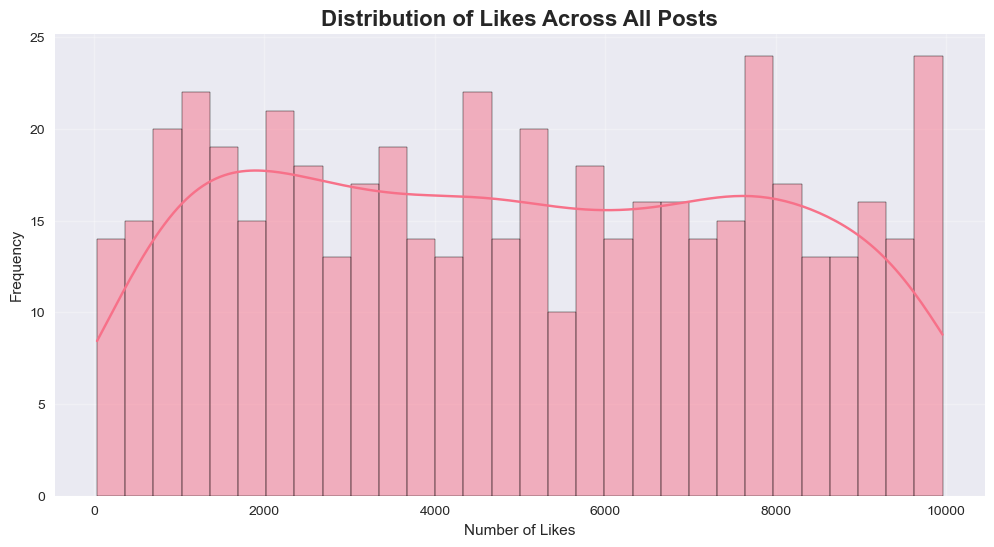

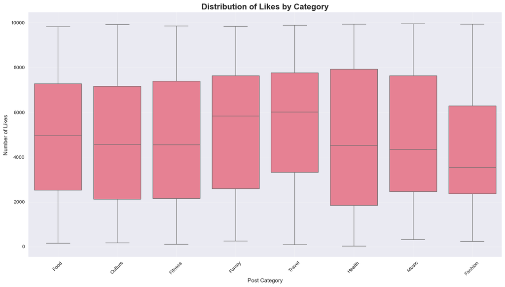

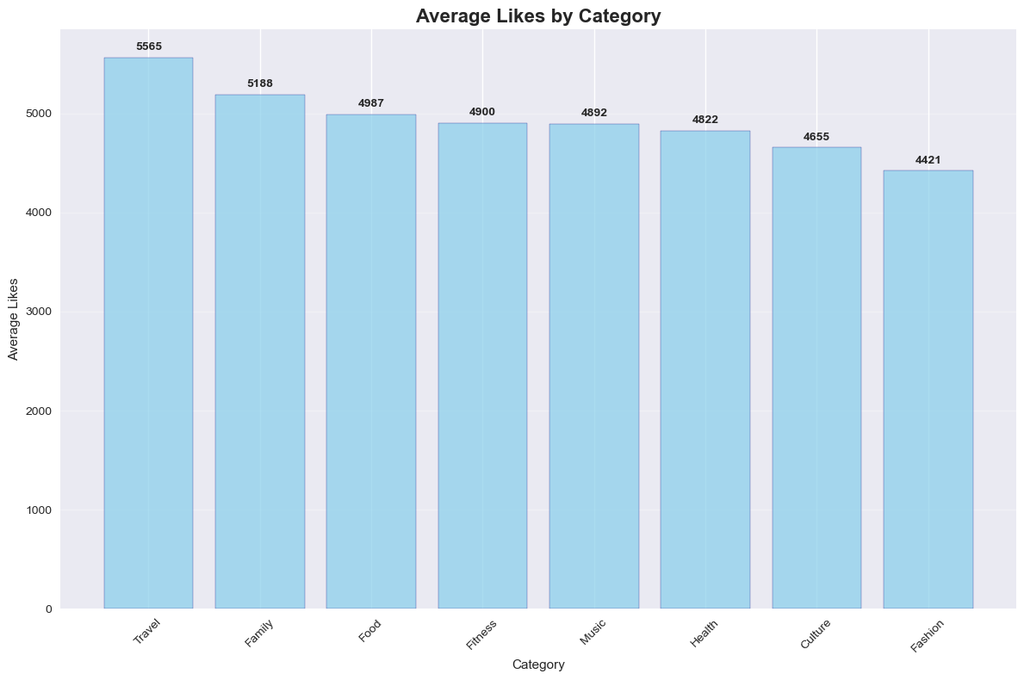

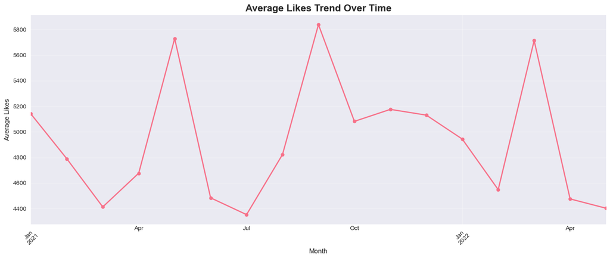

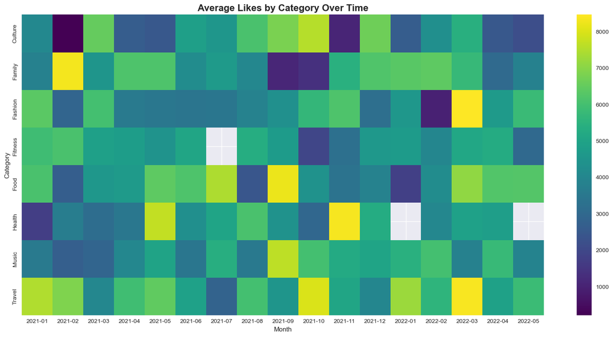

```
==================================================
STATISTICAL ANALYSIS RESULTS
==================================================

OVERALL PERFORMANCE:
Total Posts: 500
Average Likes: 4944
Median Likes: 4871
Standard Deviation: 2908
Range: 35 - 9,957

CATEGORY PERFORMANCE:
          count    mean  median     std
Category
Travel       61  5566.0  6021.0  2722.0
Family       67  5189.0  5839.0  2898.0
Food         64  4987.0  4967.0  2786.0
Fitness      67  4900.0  4549.0  3010.0
Music        68  4892.0  4348.0  2809.0
Health       63  4823.0  4523.0  3310.0
Culture      63  4656.0  4571.0  2845.0
Fashion      47  4421.0  3545.0  2861.0

TOP PERFORMERS:
Best: Travel (5566 avg likes)
Worst: Fashion (4421 avg likes)
Performance Gap: 1145 likes

HIGH-PERFORMING POSTS:
Posts with 90%+ performance: 50
Top 10% threshold: 9066 likes

Top performing categories in high-engagement posts:
Category
Fitness    9
Health     8
Fashion    7
Travel     6
Music      6
Culture    5
Family     5
Food       4
Name: count, dtype: int64

TIME-BASED INSIGHTS:
Average likes by day of week:
DayOfWeek
Friday       5363.0
Sunday       5084.0
Saturday     4930.0
Tuesday      4925.0
Wednesday    4889.0
Monday       4842.0
Thursday     4570.0
Name: Likes, dtype: float64
```

```python
# 5. DATA ANALYSIS & VISUALIZATION
# ================================

# Set up plotting style for better visuals
plt.style.use('seaborn-v0_8')
sns.set_palette("husl")
plt.rcParams['figure.figsize'] = (10, 6)

# 5.1 DISTRIBUTION ANALYSIS
# -------------------------

# Histogram of Likes Distribution
plt.figure(figsize=(12, 6))
sns.histplot(df['Likes'], bins=30, kde=True)
plt.title('Distribution of Likes Across All Posts', fontsize=16, fontweight='bold')
plt.xlabel('Number of Likes')
plt.ylabel('Frequency')
plt.grid(True, alpha=0.3)
plt.show()

# 5.2 CATEGORY PERFORMANCE ANALYSIS
# ---------------------------------

# Boxplot comparing categories
plt.figure(figsize=(14, 8))
sns.boxplot(x='Category', y='Likes', data=df)
plt.title('Distribution of Likes by Category', fontsize=16, fontweight='bold')
plt.xlabel('Post Category')
plt.ylabel('Number of Likes')
plt.xticks(rotation=45)
plt.grid(True, alpha=0.3)
plt.tight_layout()
plt.show()

# Bar plot of average likes by category
plt.figure(figsize=(12, 8))
avg_likes = df.groupby('Category')['Likes'].mean().sort_values(ascending=False)
bars = plt.bar(avg_likes.index, avg_likes.values, color='skyblue', edgecolor='navy', alpha=0.7)
plt.title('Average Likes by Category', fontsize=16, fontweight='bold')
plt.xlabel('Category')
plt.ylabel('Average Likes')
plt.xticks(rotation=45)
plt.grid(True, alpha=0.3, axis='y')

# Add value labels on bars
for bar in bars:
    height = bar.get_height()
    plt.text(bar.get_x() + bar.get_width()/2., height + 50,
             f'{int(height)}', ha='center', va='bottom', fontweight='bold')
plt.tight_layout()
plt.show()

# 5.3 TIME SERIES ANALYSIS
# ------------------------

# Convert to monthly data for trend analysis
df['Month'] = df['Date'].dt.to_period('M')
monthly_avg = df.groupby('Month')['Likes'].mean()

plt.figure(figsize=(14, 6))
monthly_avg.plot(kind='line', marker='o', linewidth=2, markersize=6)
plt.title('Average Likes Trend Over Time', fontsize=16, fontweight='bold')
plt.xlabel('Month')
plt.ylabel('Average Likes')
plt.grid(True, alpha=0.3)
plt.xticks(rotation=45)
plt.tight_layout()
plt.show()

# 5.4 CORRELATION ANALYSIS
# ------------------------

# Heatmap of category vs time period
pivot_table = df.pivot_table(values='Likes', index='Category', columns='Month', aggfunc='mean')
plt.figure(figsize=(16, 8))
sns.heatmap(pivot_table, cmap='viridis', annot=False, fmt='.0f')
plt.title('Average Likes by Category Over Time', fontsize=16, fontweight='bold')
plt.xlabel('Month')
plt.ylabel('Category')
plt.tight_layout()
plt.show()

# 5.5 STATISTICAL ANALYSIS
# ------------------------

print("="*50)
print("STATISTICAL ANALYSIS RESULTS")
print("="*50)

# Overall statistics
print(f"\nOVERALL PERFORMANCE:")
print(f"Total Posts: {len(df):,}")
print(f"Average Likes: {df['Likes'].mean():.0f}")
print(f"Median Likes: {df['Likes'].median():.0f}")
print(f"Standard Deviation: {df['Likes'].std():.0f}")
print(f"Range: {df['Likes'].min()} - {df['Likes'].max():,}")

# Category statistics
print(f"\nCATEGORY PERFORMANCE:")
category_stats = df.groupby('Category')['Likes'].agg(['count', 'mean', 'median', 'std']).round(0)
category_stats = category_stats.sort_values('mean', ascending=False)
print(category_stats)

# Top and bottom performers
print(f"\nTOP PERFORMERS:")
best_category = category_stats.index[0]
worst_category = category_stats.index[-1]
print(f"Best: {best_category} ({category_stats.loc[best_category, 'mean']:.0f} avg likes)")
print(f"Worst: {worst_category} ({category_stats.loc[worst_category, 'mean']:.0f} avg likes)")
print(f"Performance Gap: {category_stats.loc[best_category, 'mean'] - category_stats.loc[worst_category, 'mean']:.0f} likes")

# High-performing posts analysis
print(f"\nHIGH-PERFORMING POSTS:")
top_10_percent = df['Likes'].quantile(0.9)
high_performers = df[df['Likes'] >= top_10_percent]
print(f"Posts with 90%+ performance: {len(high_performers)}")
print(f"Top 10% threshold: {top_10_percent:.0f} likes")
print("\nTop performing categories in high-engagement posts:")
print(high_performers['Category'].value_counts())

# Time-based insights
print(f"\nTIME-BASED INSIGHTS:")
df['DayOfWeek'] = df['Date'].dt.day_name()
daily_avg = df.groupby('DayOfWeek')['Likes'].mean().sort_values(ascending=False)
print("Average likes by day of week:")
print(daily_avg.round(0))
```

## Insights Summary

### 3. High-Performing Posts

- The top 10 percent of posts (above 9066 likes) span multiple categories, with **Fitness** and **Health** leading in frequency.
- This suggests that while Travel has the highest average, categories like Fitness and Health can produce viral content under the right conditions.

## Recommendations

### 1. Prioritize High-Average Categories

Focus client content strategy on **Travel**, **Family**, and **Food** categories to maximize baseline engagement. These categories consistently outperform others and offer reliable returns.